# Practical ML - Week 3

Aura Frizzati

# **Week 3: Predicting with trees, Random Forests, & Model Based Predictions**

## **Week 3.1: Predicting with trees**

### **Key ideas**

- Iteratively split the outcome by splitting the predictive variables into groups
- Evaluate “homogeneity” of the outcome within each group
- Split again if necessary, until you get outcomes that are separated into groups that are **homogeneous enough** or that are **small enough**.

**Pros**  
- Easy to interpret  
- Better performance in non-linear settings (in comparison to linear regression models)

**Cons**  
- Without pruning/cross-validation, can lead to overfitting  
- Harder to estimate uncertainty (in comparison to linear regression models)  
- Results may be variable and depending on the exact values of parameters or the variables that have been collected

### **Basic algorithm**

1. Start with all variables in one group
2. Find the variable/split that best separates the outcome into two different homogenous groups
3. Divide the data into 2 groups (‘leaves’) on that split (‘node’)
4. Within each split, find the best variable/split (including variables we have already used to split the groups) that separates the outcome
5. Continue until the groups are too small or sufficiently ‘pure’ (i.e. homogenous)

### **Measures of impurity**

They are all based on this probability which can be estimated:
$$\hat{p}_{mk} = \frac{1}{N_m}\sum_{x_i\, in\, Leaf\, m}(y_i = k)$$
Within a particular group (the $m$ leaf) you have $N_m$ total objects you might consider. You can count the number of times that a particular class ($y_i = k$) appears in that leaf.

- **Misclassification error:**
  $$1 - \hat{p}_{mk(m)}$$
  $k(m)$ being the most common k outcome class in the dataset

**misclassification error** = 0 –> perfect purity (no misclassification error)  
**misclassification error** = 0.5 –> no purity

- **Gini index:**
  $$\sum_{k\neq k'} \hat{p}_{mk}*\hat{p}_{mk'} = \sum_{k=1}^{K}\hat{p}_{mk}(1-\hat{p}_{mk}) = 1-\sum_{k=1}^{K}\hat{p}^2_{mk}$$
  (to not confuse it with the Gini coefficient used in economics!)

The Gini index is 1 - the sum of the squared probability that a sample belongs to any of the different outcome classes. **Gini index** = 0 –> perfect purity (this implies one outcome class has classification probability = 1, while all the others 0)  
**Gini index** = 0.5 –> no purity (all of the classes are perfectly balanced within each leaf)

- **Deviance/information gain:**
  $$-\sum_{k=1}^{K}\hat{p}_{mk}log_2{[\hat{p}_{mk}]}$$
  This measure is called **deviance** if you use $ln$ or otherwise **information gain** using $log_2$. **Deviance/information gain** = 0 –> perfect purity **Deviance/information gain** = 1 –> no purity

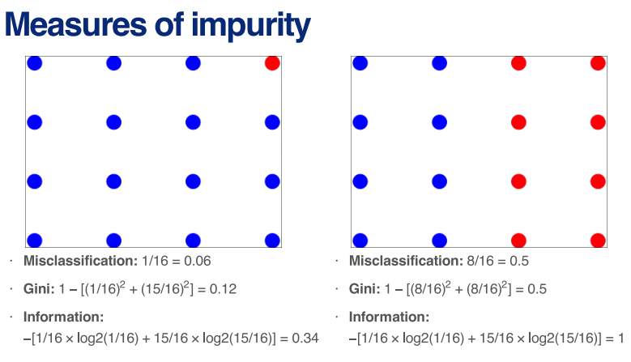

In the example above, the left panel represents a relatively pure split, while the right one is extremely impure.

### **Example: Iris data**

```r
data(iris); library(ggplot2)
names(iris)
```

```
## [1] "Sepal.Length" "Sepal.Width"  "Petal.Length" "Petal.Width"  "Species"
```

```r
table(iris$Species)
```

```
##
##     setosa versicolor  virginica
##         50         50         50
```

```r
library(caret)
inTrain<-createDataPartition(y = iris$Species, p=0.7,list=F)
training<-iris[inTrain,]
testing<-iris[-inTrain,]
dim(training);dim(testing)
```

```
## [1] 105   5
```

```
## [1] 45  5
```

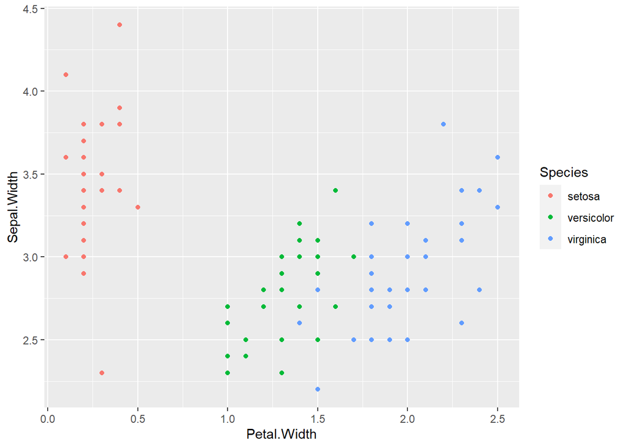

```r
qplot(Petal.Width, Sepal.Width, colour = Species, data= training)
```

There are 3 very distinct classes, although it could be challenging to predict them for a linear model (but a classification tree would be able to handle non linearity).

```r
modFit<-train(Species ~ .,method = 'rpart', data = training)
print(modFit$finalModel)
```

```
## n= 105
##
## node), split, n, loss, yval, (yprob)
##       * denotes terminal node
##
## 1) root 105 70 setosa (0.3333333 0.3333333 0.3333333)
##   2) Petal.Length< 2.45 35  0 setosa (1.0000000 0.0000000 0.0000000) *
##   3) Petal.Length>=2.45 70 35 versicolor (0.0000000 0.5000000 0.5000000)
##     6) Petal.Length< 4.75 32  1 versicolor (0.0000000 0.9687500 0.0312500) *
##     7) Petal.Length>=4.75 38  4 virginica (0.0000000 0.1052632 0.8947368) *
```

`rpart` is an R package for doing regression and classification trees.  
`modFit$finalModel` tells you what the final nodes/leaves are, how they split, and the probability for each class to be in each split.

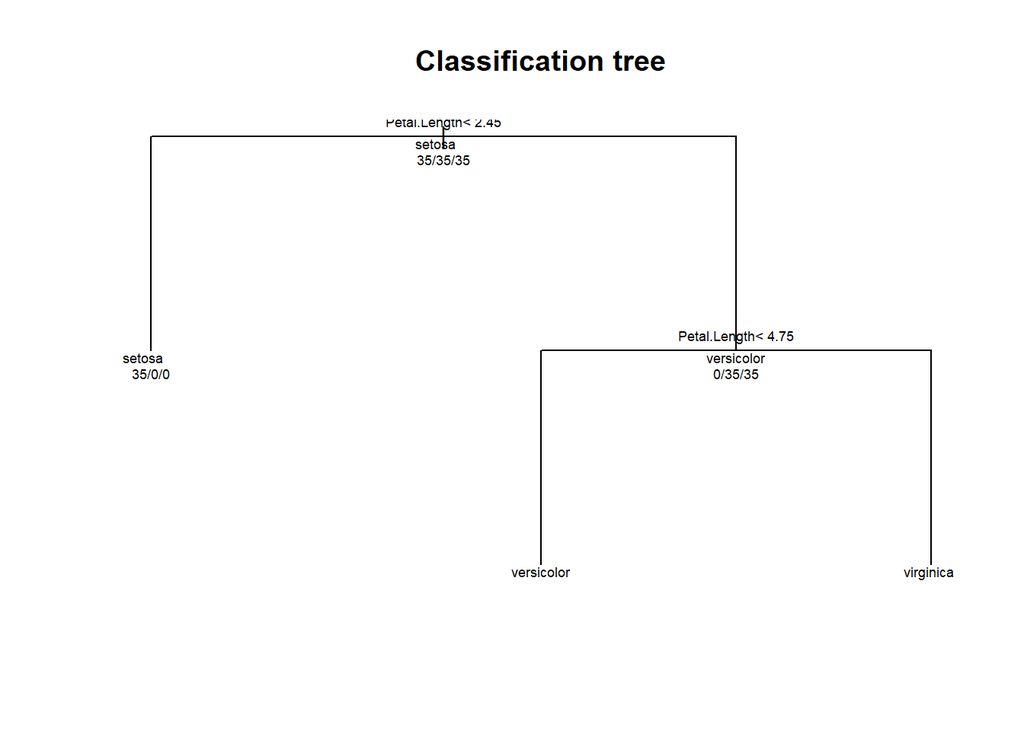

```r
plot(modFit$finalModel, uniform = T, main = "Classification tree")
text(modFit$finalModel, use.n = T, all = T, cex =.55)
```

This is a **dendogram**. The branch to the left denotes when the condition is true, while the branch to the right when it is false.

A prettier version of the same plot can be made with the `rattle` package:

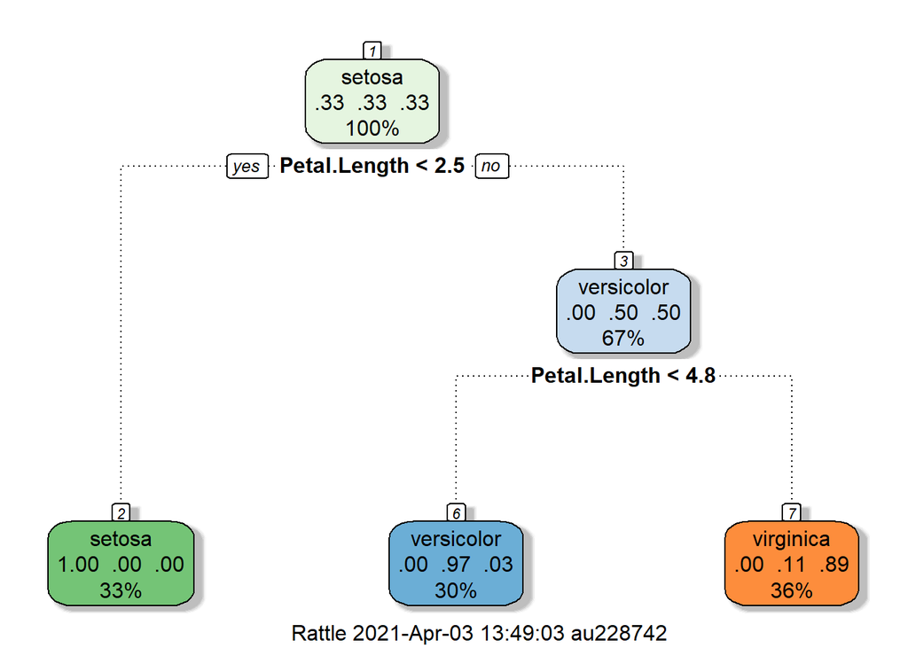

```r
library(rattle)
fancyRpartPlot(modFit$finalModel)
```

You can predict new values using the `predict` function:

```r
predict(modFit,newdata = testing)
```

```
##  [1] setosa     setosa     setosa     setosa     setosa     setosa
##  [7] setosa     setosa     setosa     setosa     setosa     setosa
## [13] setosa     setosa     setosa     versicolor virginica  versicolor
## [19] versicolor versicolor versicolor versicolor virginica  versicolor
## [25] versicolor versicolor versicolor versicolor versicolor versicolor
## [31] virginica  virginica  virginica  virginica  virginica  virginica
## [37] virginica  virginica  virginica  virginica  virginica  virginica
## [43] virginica  virginica  virginica
## Levels: setosa versicolor virginica
```

### **Final notes**

- Classification trees are **non-linear models**
  - They use **interactions** between variables
  - Data transformation may be less important (monotone transformations)
  - Trees can also be used for regression problems (continuous outcome)
- Note that there are multiple tree building options in R, both in the caret package (`party`, `rpart`) and out of it (`tree`)

https://www.amazon.com/Classification-Regression-Trees-Leo-Breiman/dp/0412048418

## **Week 3.2: Bagging**

When you fit complicated models, sometimes if you average them together you get a smoother model fit that gives a better balance between potential bias and varianc ein your fit.

### **Boostrap aggregating (bagging)**

- Basic idea:
  1. **Resample cases** (similarly to what is done in boostrapping) and **re-calculate predictions**
  2. **Average** or **majority** of votes from the predictors you have built in this way
- Notes:
  - Similar bias (to the bias you would obtain by fitting any of those models individually)
  - **Reduce variance** (because you have averaged a bunch of predictors together)
  - More useful for **non-linear functions** (e.g. trees or smoothing)

### **Example on the Ozone data**

```r
ozone<-read.csv("practical ML course/data/ozone_data.csv", header = T)
ozone<-ozone[order(ozone$ozone),]
head(ozone); dim(ozone)
```

```
##     ozone radiation temperature wind
## 17      1         8          59  9.7
## 19      4        25          61  9.7
## 14      6        78          57 18.4
## 45      7        48          80 14.3
## 106     7        49          69 10.3
## 7       8        19          61 20.1
```

```
## [1] 111   4
```

The objective is to predict ‘temperature’ as a function of ‘ozone’.

### **Bagged LOESS (Locally Estimated Scatterplot Smoothing)**

**Local regression** or **local polynomial regression**,also known as **moving regression**, is a generalization of moving average and polynomial regression. Its most common methods, initially developed for **scatterplot smoothing**, are **LOESS** (locally estimated scatterplot smoothing) and **LOWESS** (locally weighted scatterplot smoothing). They are two strongly related **non-parametric regression methods** that combine **multiple regression models** in a **k-nearest-neighbor-based meta-model**.

LOESS is a kind of smooth curve that fits through the data. It is similar to a spline model fitting.

```r
ll<-matrix(NA,nrow=10,ncol=155)
for(i in 1:10){
  ss<-sample(1:dim(ozone)[1], replace = T) #dim(ozone)[1] = N rows in ozone df
  ozone0<-ozone[ss,] # resampled dataset
  ozone0<-ozone0[order(ozone0$ozone),]
  # the 'span' for loess measures how smooth the fit will be
  loess0<-loess(temperature ~ ozone, data = ozone0, span = 0.2)
  ll[i,]<-predict(loess0,newdata=data.frame(ozone=1:155))
}
head(ll)
```

```
##          [,1]     [,2]     [,3]     [,4]     [,5]     [,6]     [,7]     [,8]
## [1,]       NA       NA       NA       NA       NA 64.89773 70.19492 72.74249
## [2,]       NA       NA       NA 61.21997 62.32309 63.77131 66.03722 70.73670
## [3,]       NA       NA       NA       NA       NA 59.19743 65.10268 69.35389
## [4,] 56.39602 59.63955 62.63709 65.31734 67.87637 70.38038 72.56327 74.15892
## [5,]       NA       NA       NA       NA       NA 60.13440 67.21734 71.16277
## [6,] 59.00478 60.67643 62.22088 63.63669 64.92240 66.07655 67.09770 67.93454
##          [,9]    [,10]    [,11]    [,12]    [,13]    [,14]    [,15]    [,16]
## [1,] 73.25019 73.30859 74.73348 73.35884 70.50015 69.60005 71.99031 72.77043
## [2,] 73.22719 71.54321 68.58573 69.19598 71.17019 71.52438 70.93746 70.01851
## [3,] 71.16744 73.11886 73.83053 73.07516 70.67103 65.90210 71.03505 76.33333
## [4,] 74.90121 73.17130 69.54214 67.03530 66.96636 69.67536 74.03955 77.16881
## [5,] 72.77666 72.07993 70.30595 69.95828 68.41948 68.22835 73.25946 77.00663
## [6,] 68.32931 68.96017 69.55882 70.23541 73.71745 71.99616 72.84947 72.78788
##         [,17]    [,18]    [,19]    [,20]    [,21]    [,22]    [,23]    [,24]
```

[output cut: 125 more lines]

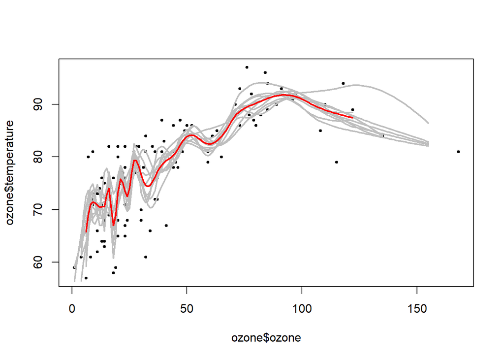

```r
plot(ozone$ozone,ozone$temperature, pch = 19, cex =0.5)
for(i in 1:10){lines(1:155, ll[i,], col='grey',lwd=2)}
lines(1:155, apply(ll,2,mean),col='red', lwd=2)
```

- In the plot, each grey line represents the LOESS fit with one resampled dataset. - The grey lines have a lot of curviness and possibly overfit the dataset variability. - The red line is the average of all the fitted grey curves.

There is a proof that shows the **bagging estimate** will always have **lower variability** but **similar bias** to each of the **individual model fits** from which it has been created.

### **Bagging in caret**

There are some models that automatically perform bagging for you –> in the `train` function consider these `method` options: - `bagEarth` - `treebag` - `bagFDA`

Alternatively, you can bag any model you choose using the `bag` function.

### **Example of custom bagging**

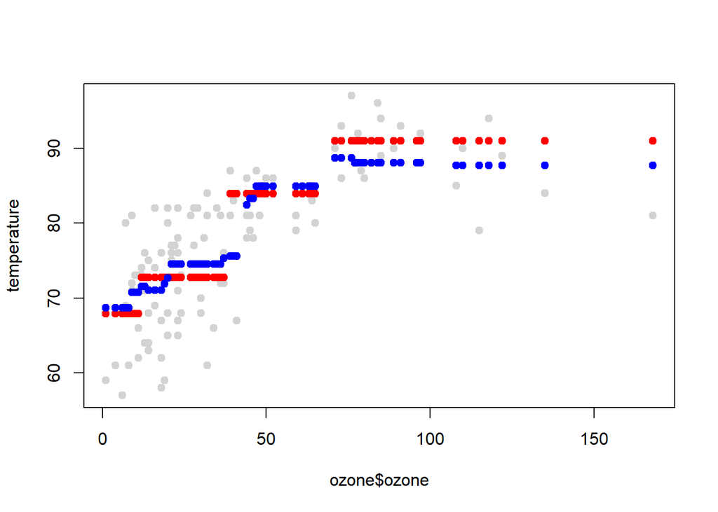

```r
predictors = data.frame(ozone=ozone$ozone) ## predictor/s
temperature = ozone$temperature ## outcome variable
treebag<-bag(predictors, temperature, B=10, ## B = n of subsamples to take

             # wit bagControl we specify how to fit the model:
             bagControl = bagControl(fit = ctreeBag$fit, ## function to be applied to train the model using each replicated subsample (the train function of the caret package can be called here as well)
                                     predict = ctreeBag$pred, ## call the predict function from the train model
                                     aggregate = ctreeBag$aggregate) ## it specifies how to put all predictions together (e.g. take average)
             )
plot(ozone$ozone, temperature, col = 'lightgrey', pch =19)
points(ozone$ozone, predict(treebag$fits[[1]]$fit, predictors), pch =19, col='red')
points(ozone$ozone, predict(treebag, predictors), pch =19, col='blue')
```

- The grey dots represent actual data points - The red dots represent the fit from a single conditional regression tree (it does not capture the data trend very well) - The blue dots represent the fit from the bag regression (i.e. average of the single regression predictions) –> data trends are captured better!

#### **Parts of bagging**

```r
ctreeBag$fit
```

```
## function (x, y, ...)
## {
##     loadNamespace("party")
##     data <- as.data.frame(x, stringsAsFactors = TRUE)
##     data$y <- y
##     party::ctree(y ~ ., data = data)
## }
## <bytecode: 0x00000000278cf198>
## <environment: namespace:caret>
```

- The `ctreeBag$fit` function takes the predictor df (`x`) and the predictor (`y`) and calls the function `ctree` to train a **conditional regression tree** on the dataset. The model fit is returned.

```r
ctreeBag$pred
```

```
## function (object, x)
## {
##     if (!is.data.frame(x))
##         x <- as.data.frame(x, stringsAsFactors = TRUE)
##     obsLevels <- levels(object@data@get("response")[, 1])
##     if (!is.null(obsLevels)) {
##         rawProbs <- party::treeresponse(object, x)
##         probMatrix <- matrix(unlist(rawProbs), ncol = length(obsLevels),
##             byrow = TRUE)
##         out <- data.frame(probMatrix)
##         colnames(out) <- obsLevels
##         rownames(out) <- NULL
##     }
##     else out <- unlist(party::treeresponse(object, x))
##     out
## }
## <bytecode: 0x00000000278cfbe0>
## <environment: namespace:caret>
```

- The `ctreeBag$pred` function takes as input the object created by the `ctreeBag$fit`. The new outcomes from the object and data input are calculated using `treeresponse`.
- These predicted values are then used by the next aggregation function and pooled together (in the example, the `median` prediction is used as pooled outcome prediction):

```r
ctreeBag$aggregate
```

```
## function (x, type = "class")
## {
##     if (is.matrix(x[[1]]) | is.data.frame(x[[1]])) {
##         pooled <- x[[1]] & NA
##         classes <- colnames(pooled)
##         for (i in 1:ncol(pooled)) {
##             tmp <- lapply(x, function(y, col) y[, col], col = i)
##             tmp <- do.call("rbind", tmp)
##             pooled[, i] <- apply(tmp, 2, median)
##         }
##         if (type == "class") {
##             out <- factor(classes[apply(pooled, 1, which.max)],
##                 levels = classes)
##         }
##         else out <- as.data.frame(pooled, stringsAsFactors = TRUE)
##     }
##     else {
##         x <- matrix(unlist(x), ncol = length(x))
##         out <- apply(x, 1, median)
##     }
##     out
## }
## <bytecode: 0x00000000278cb4f0>
## <environment: namespace:caret>
```

- Bagging is most useful for nonlinear models.
- It is often used with trees. One of its extension is **random forests**.
- Several models use bagging in caret’s `train` function.

https://stat.ethz.ch/education/semesters/FS_2008/CompStat/sk-ch8.pdf

## **Week 3.3: Random forests**

They can be defined as an extension to bagging for classification and regression trees.

1. **Booststrap samples**
2. **At each split, boostrap variables** (thus, only a subset of the variables is considered at each potential split. In this way, a diverse set of potential trees can be built)
3. **Grow multiple** (large number) **trees** and vote (or take the average of predictions)

**Pros**: - **Accuracy**

**Cons**: - **Low speed** (slow as it needs to build a large number of trees) - ***Poor interpretability** (as the model relies on **bootstrapped samples** with **bootstrapped nodes**) - **Overfitting** (hard to understand which trees are leading to overfitting –> very important to use **crossvalidation**)

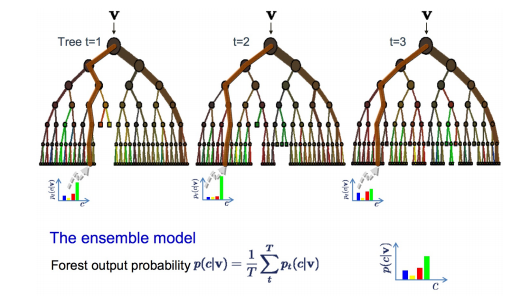

- The basic idea is that you build a large number of trees (T), each created from a bootstrap sample.
- At each node of one tree we allow a subsample of the variables to potentially contribute to the splits.
- The same observation (**v** in the figure above) will end up at possibly a different leaf at the bottom of each tree, corresponding to a particular prediction.
- All the different predictions from all the prediction trees are then averaged (**ensemble model**) to create the final class (c) prediction for the observation (v).

### **Iris data example**

```r
data(iris);library(ggplot2);library(caret);library(randomForest)
inTrain<-createDataPartition(y=iris$Species, p=0.7,list=F)
training<-iris[inTrain,]
testing<-iris[-inTrain,]
summary(training)
```

```
##   Sepal.Length    Sepal.Width     Petal.Length    Petal.Width
##  Min.   :4.300   Min.   :2.000   Min.   :1.100   Min.   :0.100
##  1st Qu.:5.100   1st Qu.:2.800   1st Qu.:1.500   1st Qu.:0.300
##  Median :5.800   Median :3.000   Median :4.400   Median :1.300
##  Mean   :5.823   Mean   :3.055   Mean   :3.749   Mean   :1.209
##  3rd Qu.:6.400   3rd Qu.:3.300   3rd Qu.:5.100   3rd Qu.:1.800
##  Max.   :7.900   Max.   :4.400   Max.   :6.900   Max.   :2.500
##        Species
##  setosa    :35
##  versicolor:35
##  virginica :35
##
##
##
```

```r
### RANDOM FORESTS
modFit<-train(data=training,Species ~ .,method='rf',prox=T)# 'rf' = random forest,
# prox=T is to allow to visualise class centers (see below)
modFit
```

```
## Random Forest
##
## 105 samples
##   4 predictor
##   3 classes: 'setosa', 'versicolor', 'virginica'
##
## No pre-processing
## Resampling: Bootstrapped (25 reps)
## Summary of sample sizes: 105, 105, 105, 105, 105, 105, ...
## Resampling results across tuning parameters:
##
##   mtry  Accuracy   Kappa
##   2     0.9533341  0.929197
##   3     0.9533341  0.929197
##   4     0.9533341  0.929197
##
## Accuracy was used to select the optimal model using the largest value.
## The final value used for the model was mtry = 2.
```

A bunch of different tuning parameters were tried during training –> `mtry` = Number of variables randomly sampled as candidates at each split

```r
getTree(modFit$finalModel,k=2) # k specifies which tree we want to examine (number 2 in this case)
```

```
##    left daughter right daughter split var split point status prediction
## 1              2              3         1        5.45      1          0
## 2              4              5         4        0.75      1          0
## 3              6              7         4        1.75      1          0
## 4              0              0         0        0.00     -1          1
## 5              8              9         3        4.20      1          0
## 6             10             11         4        0.60      1          0
## 7             12             13         2        3.15      1          0
## 8              0              0         0        0.00     -1          2
## 9              0              0         0        0.00     -1          3
## 10             0              0         0        0.00     -1          1
## 11             0              0         0        0.00     -1          2
## 12             0              0         0        0.00     -1          3
## 13            14             15         3        5.05      1          0
## 14             0              0         0        0.00     -1          2
## 15             0              0         0        0.00     -1          3
```

- Each row corresponds to a split
- “var split” is the variable that was used for the split
- “split point” is the value of the variable used for the split

### **Class ‘centers’**

- They specify the centers of the class predictions:

```r
library(randomForest);library(ggplot2)
#training[,c(3,4)] denote the two predictors to represent in the plot:
irisP<-classCenter(training[,c(3,4)],training$Species, modFit$finalModel$prox) ##prox is used here
irisP<-as.data.frame(irisP);irisP$Species<-rownames(irisP)
irisP
```

```
##            Petal.Length Petal.Width    Species
## setosa              1.4         0.2     setosa
## versicolor          4.4         1.3 versicolor
## virginica           5.5         2.0  virginica
```

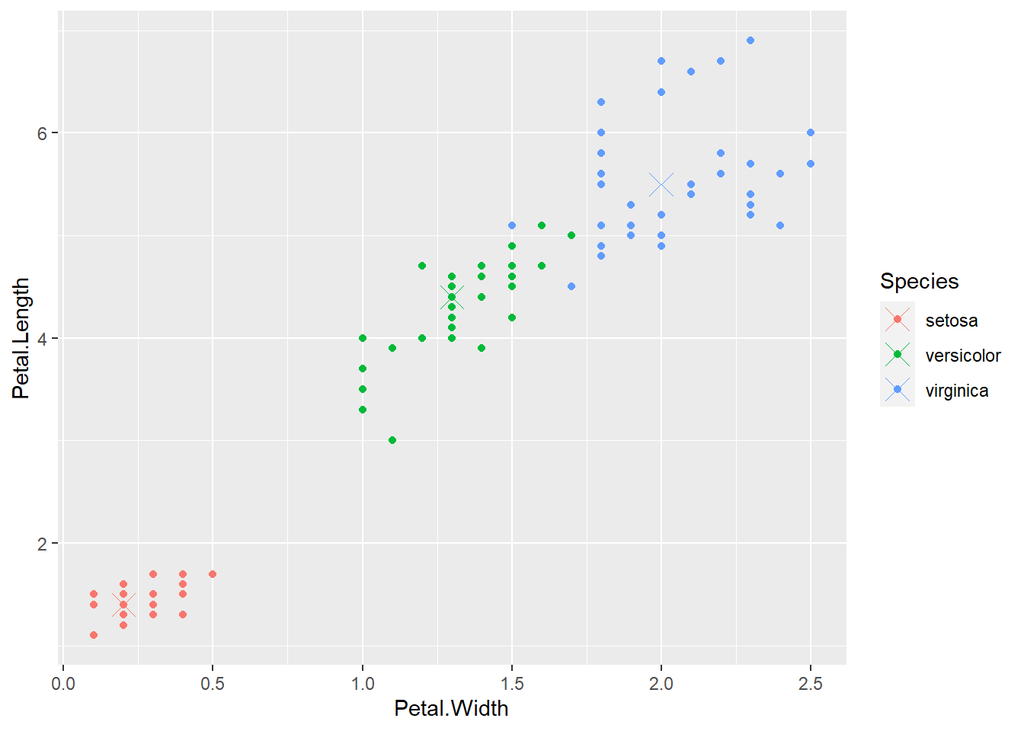

```r
p<-qplot(Petal.Width,Petal.Length,col=Species,data=training)
p + geom_point(aes(x=Petal.Width,y=Petal.Length,col=Species), size=5,shape=4,data=irisP)
```

### **Predicting new values**

```r
library(caret)
pred<-predict(modFit,testing)
testing$predRight<-pred == testing$Species
table(pred,testing$Species)
```

```
##
## pred         setosa versicolor virginica
##   setosa         15          0         0
##   versicolor      0         15         3
##   virginica       0          0        12
```

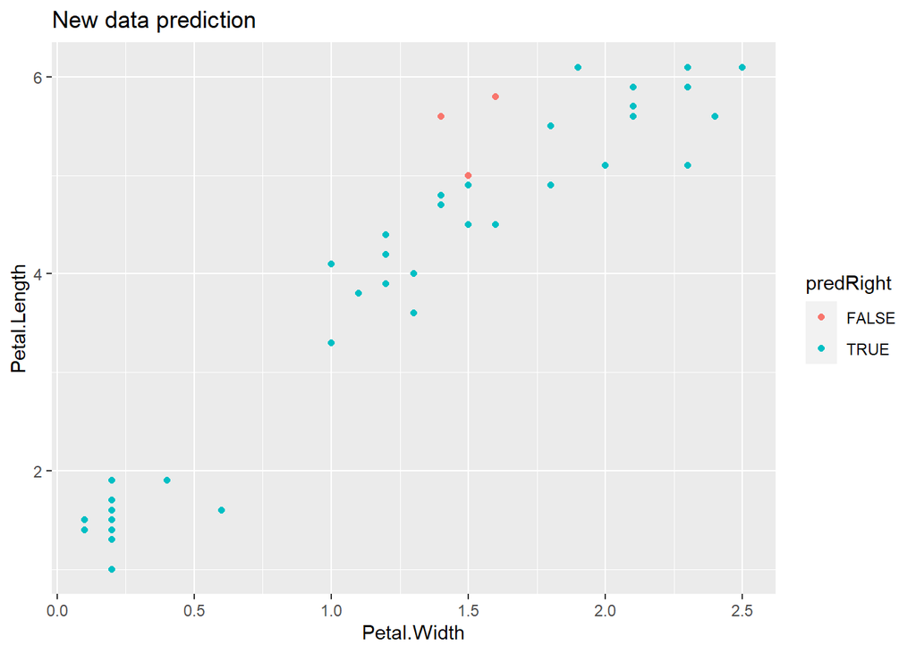

```r
qplot(Petal.Width,Petal.Length,colour=predRight, data=testing, main = 'New data prediction')
```

```r
confusionMatrix(pred,testing$Species)
```

```
## Confusion Matrix and Statistics
##
##             Reference
## Prediction   setosa versicolor virginica
##   setosa         15          0         0
##   versicolor      0         15         3
##   virginica       0          0        12
##
## Overall Statistics
##
##                Accuracy : 0.9333
##                  95% CI : (0.8173, 0.986)
##     No Information Rate : 0.3333
##     P-Value [Acc > NIR] : < 2.2e-16
##
##                   Kappa : 0.9
##
##  Mcnemar's Test P-Value : NA
##
## Statistics by Class:
##
##                      Class: setosa Class: versicolor Class: virginica
## Sensitivity                 1.0000            1.0000           0.8000
## Specificity                 1.0000            0.9000           1.0000
## Pos Pred Value              1.0000            0.8333           1.0000
## Neg Pred Value              1.0000            1.0000           0.9091
## Prevalence                  0.3333            0.3333           0.3333
## Detection Rate              0.3333            0.3333           0.2667
## Detection Prevalence        0.3333            0.4000           0.2667
## Balanced Accuracy           1.0000            0.9500           0.9000
```

### **Notes and further resources**

- Random forests are usually one of the top performing algorithms along with boosting in prediction contests.
- Random forests are **difficult to interpret** but **very accurate**.
- Care should be taken to avoid overfitting, using cross-validation with the rf library (see `rfcv` function: https://cran.r-project.org/web/packages/randomForest/randomForest.pdf) or indirectly via caret.
- Website of creator of random forests: https://www.stat.berkeley.edu/~breiman/RandomForests/cc_home.htm

## **Week 3.4: Boosting**

### **Key ideas**

1. Take lots of (possibly) weak predictors
2. Weight them (to take advantage of their strength) and add them up
3. Get a stronger predictor

### **Basic idea behind boosting**

1. Start with a **set of classifiers** $h_1,...,h_k$ They are usually from the same class of classifiers (examples: all possible trees, all possible regression models, all possible cutoffs).
2. Create a classifier that **combines classification functions**: $f(x)=\rm{sgn}\left(\sum_{t=1}^{T}a_th_t(x)\right)$ ($a_t$ is a weight, $h_t(x)$ is a classifier)
- Goal is to **minimise error** (on training set)
- **Iterative**: select one $h$ at each step
- Calculate **weights based on errors**
- Upweight missed classifications and select next $h$

The most famous boosting algorithm is **Ada boosting**.

### **Simple example**

https://alliance.seas.upenn.edu/~cis520/dynamic/2020/wiki/index.php?n=Lectures.Boosting

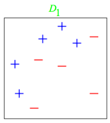

- We are trying to separate the +/blue category form the -/red category using 2 dimensions/predictors (X- and Y-axes)

### **Round 1: adaboost**

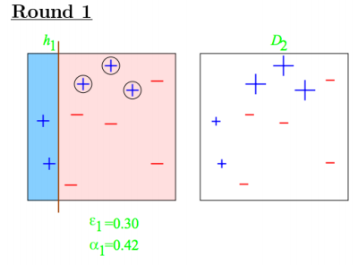

- The first classifier considers anything to the left of the red line as a +/blue and anything to the right as a -/red.
- 3 points were misclassified
- $\epsilon_1$ is the error rate
- The weight of the misclassified samples is increased (**upweighting**), so they get more importance for building the next classifier.

### **Round 2 & 3: adaboost**

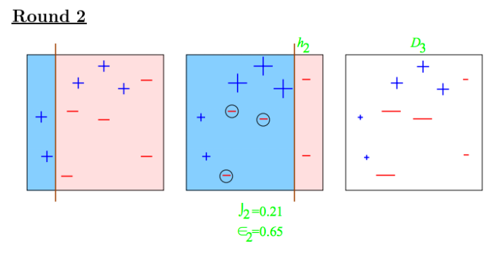

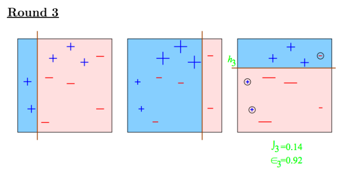

- The 2nd classifier predicts as +/blue everything to the left of the red line (3 samples misclassified)
- The 3rd classifier predicts as +/blue everything above the red line (3 samples misclassified); this classifier tries to correctly predict those sampels that were misclassified in round 1 and 2.

### **Completed classifier: adaboost**

- We take the classifiers built in the previous rounds, weight them and add them up

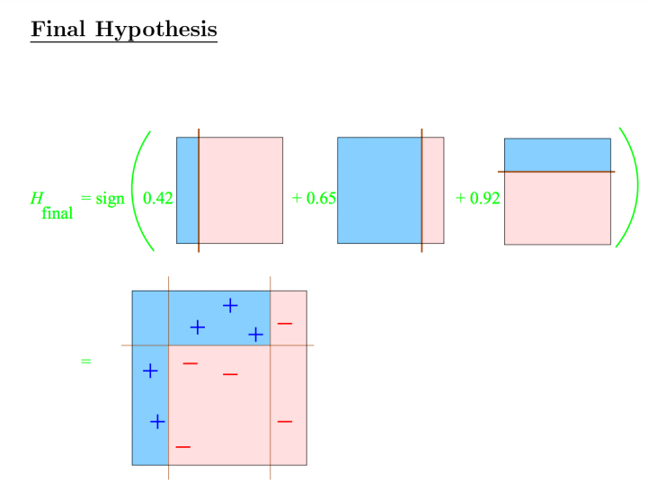

- The resulting classifier is much more accurate! It is the result of the combination of multiple naive simple classifiers (straight lines in this example).

### **Boosting in R**

- Boosting can be used with any subset of (weak) classifiers
- One large subclass is **gradient boosting**
- R has multiple boosting libraries. Differences include the choice of basic classification functions and combination rules:
  - `gbm`: boosting with trees
  - `mboost`: model based boosting
  - `ada`: statistical boosting based on additive logistic regression
  - `gamboost`: for boosting generalised additive models
- Most of these are available in the caret package

### **Wage example**

```r
library(ISLR); data(Wage);library(ggplot2); library(caret)
Wage <-subset(Wage,select=-c(logwage)) ##wage is the var want to predict
summary(Wage)
```

```
##       year           age                     maritl           race
##  Min.   :2003   Min.   :18.00   1. Never Married: 648   1. White:2480
##  1st Qu.:2004   1st Qu.:33.75   2. Married      :2074   2. Black: 293
##  Median :2006   Median :42.00   3. Widowed      :  19   3. Asian: 190
##  Mean   :2006   Mean   :42.41   4. Divorced     : 204   4. Other:  37
##  3rd Qu.:2008   3rd Qu.:51.00   5. Separated    :  55
##  Max.   :2009   Max.   :80.00
##
##               education                     region               jobclass
##  1. < HS Grad      :268   2. Middle Atlantic   :3000   1. Industrial :1544
##  2. HS Grad        :971   1. New England       :   0   2. Information:1456
##  3. Some College   :650   3. East North Central:   0
##  4. College Grad   :685   4. West North Central:   0
##  5. Advanced Degree:426   5. South Atlantic    :   0
##                           6. East South Central:   0
##                           (Other)              :   0
##             health      health_ins        wage
##  1. <=Good     : 858   1. Yes:2083   Min.   : 20.09
##  2. >=Very Good:2142   2. No : 917   1st Qu.: 85.38
##                                      Median :104.92
##                                      Mean   :111.70
##                                      3rd Qu.:128.68
##                                      Max.   :318.34
##
```

```r
inTrain<- createDataPartition(y=Wage$wage,p=0.7, list=F)
training<-Wage[inTrain,]; testing<-Wage[-inTrain,]
```

### **Fit the boosting model**

```r
modFit<-train(data= training, wage~., method = 'gbm', verbose = F) ##'gbm' to boost with trees// verbose = F, otherwise too much output is produced
modFit
```

```
## Stochastic Gradient Boosting
##
## 2102 samples
##    9 predictor
##
## No pre-processing
## Resampling: Bootstrapped (25 reps)
## Summary of sample sizes: 2102, 2102, 2102, 2102, 2102, 2102, ...
## Resampling results across tuning parameters:
##
##   interaction.depth  n.trees  RMSE      Rsquared   MAE
##   1                   50      33.76863  0.3218465  23.16669
##   1                  100      33.25502  0.3325699  22.79275
##   1                  150      33.15231  0.3363811  22.76930
##   2                   50      33.12180  0.3385880  22.65678
##   2                  100      32.99161  0.3428714  22.63563
##   2                  150      33.05016  0.3416926  22.71659
##   3                   50      33.02860  0.3412073  22.62071
##   3                  100      33.10695  0.3400929  22.79829
##   3                  150      33.26547  0.3358659  23.00757
##
## Tuning parameter 'shrinkage' was held constant at a value of 0.1
##
## Tuning parameter 'n.minobsinnode' was held constant at a value of 10
## RMSE was used to select the optimal model using the smallest value.
## The final values used for the model were n.trees = 100, interaction.depth =
##  2, shrinkage = 0.1 and n.minobsinnode = 10.
```

### **Plot the results**

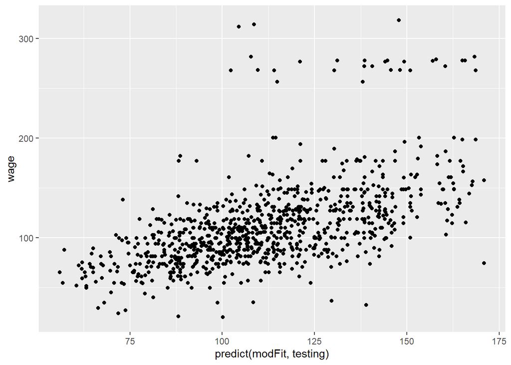

```r
qplot(predict(modFit,testing),wage,data=testing)
```

### **Notes and further reading**

- A nice tutorial for boosting: https://www.cc.gatech.edu/~thad/6601-gradAI-fall2013/boosting.pdf
- Boosting, random forests and model ensembling are the most common tools that win Kaggle and other prediction contests

## **Week 3.5: Model-based prediction**

### **Basic ideas**

1. **Assume** the data follow a **probabilistic model**
2. Use the **Bayes’ theorem** to identify optimal classifiers based on the probabilistic model previously identified.

**Pros**: - Can take advantage of structure of the data (e.g. if the data follow a specific probabilistic distribution) - May be computationally convenient - Reasonably accurate on real problems

**Cons**: - Make **additional assumptions** about the data - When the model is incorrect you may get reduced accuracy

### **Model based approach**

1. Our goal is to build a **parametric model** (a model based on probability distributions) for **conditional distribution** $P(Y = k | X = x)$ ($k$ is a specific y-outcome class)
2. A typical approach is to apply [**Bayes theorem**](http://en.wikipedia.org/wiki/Bayes'_theorem):
   $$Pr(Y = k | X=x) = \frac{Pr(X=x|Y=k)Pr(Y=k)}{\sum_{\ell=1}^K Pr(X=x |Y = \ell) Pr(Y=\ell)}$$
   $$Pr(Y = k | X=x) = \frac{f_k(x) \pi_k}{\sum_{\ell = 1}^K f_{\ell}(x) \pi_{\ell}}$$
3. Typically **prior probabilities** $\pi_k$ are set in advance (using the data).
4. A common choice for $f_k(x) = \frac{1}{\sigma_k \sqrt{2 \pi}}e^{-\frac{(x-\mu_k)^2}{\sigma_k^2}}$, a **Gaussian distribution** (might be multivariate gaussian distribution if there are multiple x variables). This is the **parametric model** for the distribution of the features (x) given the outcome class (y=k) we assume.
5. **Estimate the parameters** ($\mu_k$,$\sigma_k^2$) from the data.
6. Classify to the **class with the highest value** of $P(Y = k | X = x)$

### **Classifying using the model**

A range of models use this approach

- **Linear discriminant analysis** assumes $f_k(x)$ is **multivariate Gaussian** (i.e. the x features have a multivariate Gaussian distribution within each outcome class) with the **same covariance matrix** for each outcome class. This model draws lines through the data (called the **covariate space**)
- **Quadratic discrimant analysis** assumes $f_k(x)$ is **multivariate Gaussian** with **different covariances** (different covariance matrices are allowed for each outcome class). It draws quadratic curves through the data as opposed to lines.
- [**Model based prediction**](http://www.stat.washington.edu/mclust/) assumes **more complicated versions for the covariance matrix**
- **Naive Bayes** assumes **independence between features** for model building. This might not be true in reality, although Naive Bayes could still allow to build a useful predictor.

http://statweb.stanford.edu/~tibs/ElemStatLearn/

### **Why linear discriminant analysis?**

$$log \frac{Pr(Y = k | X=x)}{Pr(Y = j | X=x)}$$

- The $log$ is a montonous function, so when the ratio $\frac{Pr(Y = k | X=x)}{Pr(Y = j | X=x)}$ increases, also $log \frac{Pr(Y = k | X=x)}{Pr(Y = j | X=x)}$ increases.
- Using Bayes theorem, you can rewrite the first expression as:

$$= log \frac{f_k(x)}{f_j(x)} + log \frac{\pi_k}{\pi_j}$$

- The term $log \frac{f_k(x)}{f_j(x)}$ can be further transformed into two components, the first one depends on the parameters of the Gaussian/normal distributions (i.e. $\mu_k$ and $\mu_j$) …

$$= log \frac{\pi_k}{\pi_j} - \frac{1}{2}(\mu_k + \mu_j)^T \Sigma^{-1}(\mu_k + \mu_j)$$

…the second one is a **linear term** (for this reason the model draws lines through the data. A variable will have a higher probability to belong to a specific class if it is on one side of the line, and to belong to another class if it is located on the other side of the line):

$$+ x^T \Sigma^{-1} (\mu_k - \mu_j)$$

### **Decision boundaries**

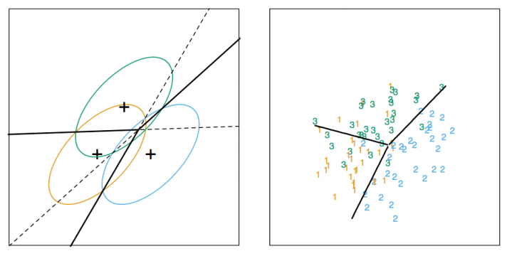

- We are trying to classify samples into 3 categories using 2 predictors (dimensions of the Cartesian axes)
- The Gaussian distributions are visible as ovals in the left panel
- Lines are drawn in the data space when the probability switches from being higher for a class to another class
- The model basically fits Gaussian distributions to the data and uses them to draw lines, classifying the points according to their highest posterior probability

### **Discriminant function**

$$\delta_k(x) = x^T \Sigma^{-1} \mu_k - \frac{1}{2}\mu_k \Sigma^{-1}\mu_k + log(\mu_k)$$

$\Sigma^{-1} \mu_k$ represent the inverse of the covraince matrix for class k (although it is the same for each class in linear discriminant analysis).

$x^T \Sigma^{-1} \mu_k$ is the linear term

- Decide on class based on $\hat{Y}(x) = argmax_k \delta_k(x)$ (i.e.the value ok $k$ which makes the discriminant function bigger for a specific sample)
- We usually estimate parameters with **maximum likelihood**

### **Naive Bayes**

Naive Bayes tries to further simplify the problem. Suppose we have many predictors, we would want to model: $P(Y = k | X_1,\ldots,X_m)$

We could use **Bayes Theorem** to get:

$$P(Y = k | X_1,\ldots,X_m) = \frac{\pi_k P(X_1,\ldots,X_m| Y=k)}{\sum_{\ell = 1}^K P(X_1,\ldots,X_m | Y=k) \pi_{\ell}}$$

It can be claimed that $P(Y = k | X_1,\ldots,X_m)$ is **proportional** to the numerator of Bayes therom (the term in the denominator is just a constant for all the different probabilities):

$$\propto \pi_k P(X_1,\ldots,X_m| Y=k)$$

This can be re-written (breaking down **conditional probabilities** until you get one term for every feature $X$):

$$P(X_1,\ldots,X_m, Y=k) = \pi_k P(X_1 | Y = k)P(X_2,\ldots,X_m | X_1,Y=k)$$
$$= \pi_k P(X_1 | Y = k) P(X_2 | X_1, Y=k) P(X_3,\ldots,X_m | X_1,X_2, Y=k)$$
$$= \pi_k P(X_1 | Y = k) P(X_2 | X_1, Y=k)\ldots P(X_m|X_1\ldots,X_{m-1},Y=k)$$

We could make an **assumption** (**if all $Xs$ were independent**) to write this (where the conditioning is dropped down):

$$\approx \pi_k P(X_1 | Y = k) P(X_2 | Y = k)\ldots P(X_m |,Y=k)$$

- Although this assumption is **naive**, it works particularly well in a number of applications (e.g. when you have a very large of binary/categorical features, for example in text/document classification applications)

### **Example: Iris Data**

```r
data(iris); library(ggplot2)
names(iris)
```

```
## [1] "Sepal.Length" "Sepal.Width"  "Petal.Length" "Petal.Width"  "Species"
```

```r
table(iris$Species)
```

```
##
##     setosa versicolor  virginica
##         50         50         50
```

### **Create training and test sets**

```r
library(caret)
inTrain<-createDataPartition(y=iris$Species, p=0.7,list = F)
training<-iris[inTrain,]
testing<-iris[-inTrain,]
dim(training); dim(testing)
```

```
## [1] 105   5
```

```
## [1] 45  5
```

### **Build predictions**

```r
modLDA<-train(data=training, Species~., method='lda')
modNB<-train(data=training, Species~., method='nb')
pdLDA<- predict(modLDA, testing)
pdNB<- predict(modNB, testing)
table(pdLDA,pdNB)
```

```
##             pdNB
## pdLDA        setosa versicolor virginica
##   setosa         15          0         0
##   versicolor      0         13         2
##   virginica       0          1        14
```

### **Comparison of results**

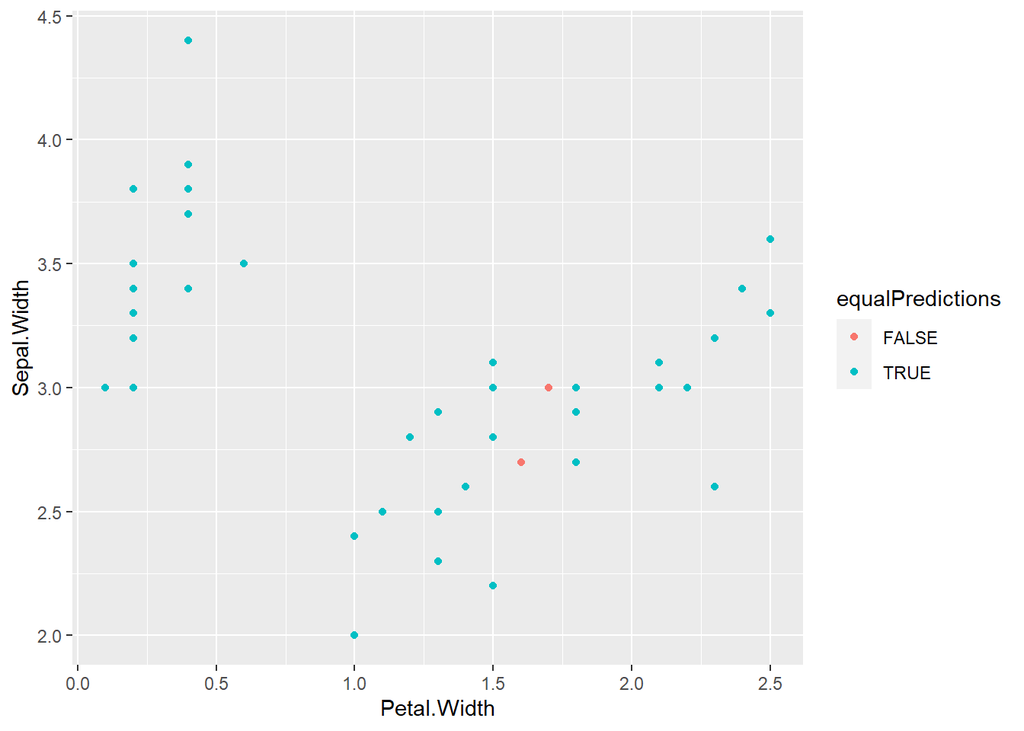

```r
equalPredictions <- (pdLDA == pdNB)
qplot(Petal.Width,Sepal.Width,colour=equalPredictions,data=testing)
```

### **Notes and further reading**

- [Introduction to statistical learning](http://www-bcf.usc.edu/~gareth/ISL/)
- [Elements of Statistical Learning](http://www-stat.stanford.edu/~tibs/ElemStatLearn/)
- [Model based clustering](http://www.stat.washington.edu/raftery/Research/PDF/fraley2002.pdf)
- [Linear Discriminant Analysis](http://en.wikipedia.org/wiki/Linear_discriminant_analysis)
- [Quadratic Discriminant Analysis](http://en.wikipedia.org/wiki/Quadratic_classifier)